# SPI e MK teste

Ivanildo Batista da Silva Júnior

7 de julho de 2021

#### Índice de Precipitação Padronizado (SPI)

O Índice de Precipitação Padronizado (SPI) foi desenvolvido por *McKee*, *Doesken*, e *Kleist* (1993) para quantificar o déficit de precipitação em múltiplas escalas de tempo (1, 3, 6, 12, 24 e 48 meses) e é recomendado pela Organização Meteorológica Mundial (OMM) para caracterizar a severidade da seca (Hayes et al., 2011). Para o cálculo do SPI, primeiro é necessário ajustar a função densidade de probabilidade (fdp) para o conjunto de dados de precipitaçãoo. Dentre as várias distribuições propostas na literatura (*Stagge et al.*, 2005; *Svensson*, *Hannaford* & *Prosdocimi*, 2017), neste trabalho, foi adotada a distribuição gama, que é amplamente utilizada para ajustar séries temporais de precipitação (McKee, Doesken & Kleist, 1993). A fdp da gama é dada por

$$f(x) = \dfrac{1}{\beta^{\alpha} \Gamma(\alpha)} x^{\alpha-1}e^{-\frac{x}{\beta}}, x>0$$
onde $\alpha > 0$ é um parâmetro de forma, $\beta > 0$ é um parâmetro de escala, $x$ é a quantidade de precipitação e $\Gamma(\alpha)$ é a função gama $\Gamma(\alpha) = \int_0^{\alpha} y_{\alpha-1}e^{-y}dy$. Os parâmetros $\alpha$ e $\beta$ são estimados usando o método de máxima verossimilhança, que produz estimativas

$$\hat{\alpha} = \dfrac{1}{4A}\bigg(1+\sqrt{1 + \dfrac{4A}{3}}\bigg), \mbox{ } \hat{\beta} = \dfrac{\overline{x}}{\hat{\alpha}}$$

$$F(x) = \int_0^{x} f(x)dx = \dfrac{1}{\hat{\beta}^{\hat{\alpha}} \Gamma(\hat{\alpha})} \int_0^{x} x^{\hat{\alpha} - 1}e^{-x/\beta}dx$$
A função gama é indefinida para $x=0$ , e como os dados de precipitação naturalmente contêm zeros, a probabilidade acumulada é considerada da seguinte forma

$$H(x) = q + (1-q)F(x)$$
onde $q$ é a probabilidade de precipitação zero, que é calculada como $q = frac{m}{n}$ , onde $m$ representa o número de zeros em uma série de precipitação e $n$ é o número de observações. Por fim, o SPI é gerado pela padronização dos valores obtidos em $H(x)$ (Lloyd‐Hughes & Saunders, 2002)

$$SPI = \left \{ \begin{matrix} -\bigg(t -\dfrac{c_0 + c_1t + c_2t^2}{1 + d_1t + d_2t^2 + d_3t^3}\bigg), & 0 < H(x) < 0.5 \\ +\bigg(t -\dfrac{c_0 + c_1t + c_2t^2}{1 + d_1t + d_2t^2 + d_3t^3}\bigg), & 0.5 < H(x) \leq 1.0 \end{matrix} \right.$$
com $c_0 = 2.515517$; $c_1 = 0.802853$; $c_2 = 0.010328$; $d_1 = 1.432788$; $d_2 = 0.189269$; $d_3 = 0.001308$ e $t$ é dado por,

$$SPI = \left \{ \begin{matrix} \sqrt{ln \bigg[ \dfrac{1}{(H(x))^2}\bigg]}, & 0 < H(x) < 0.5 \\ \sqrt{ln \bigg[ \dfrac{1}{1 - (H(x))^2} \bigg]} , & 0.5 < H(x) \leq 1.0 \end{matrix} \right.$$
*McKee*, *Doesken*, e *Kleist* (1993) categorizam o SPI em classes moderadas, severas e extremas para condições secas e úmidas, conforme mostrado na Tabela 1.

| Categoria | Valores |
| --- | --- |
| Extremamente seco | SPI < -2 |
| Severamente seco | -2 <= SPI < -1.5 |
| Moderadamente seco | -1.5 <= SPI < -1 |
| Quase normal | -1 < SPI < 1 |
| Moderadamente úmido | 1<= SPI < 1.5 |
| Severamente úmido | 1.5 <= SPI < 2 |
| Extremamente úmido | SPI > 2 |

#### Importando os pacotes

```r
library(SPEI)
library(trend)
library(Kendall)
```

#### Importando os dados

```r
chuva = read.csv('chuva.csv')
```

Gerando o gráfico da série temporal de precipitação.

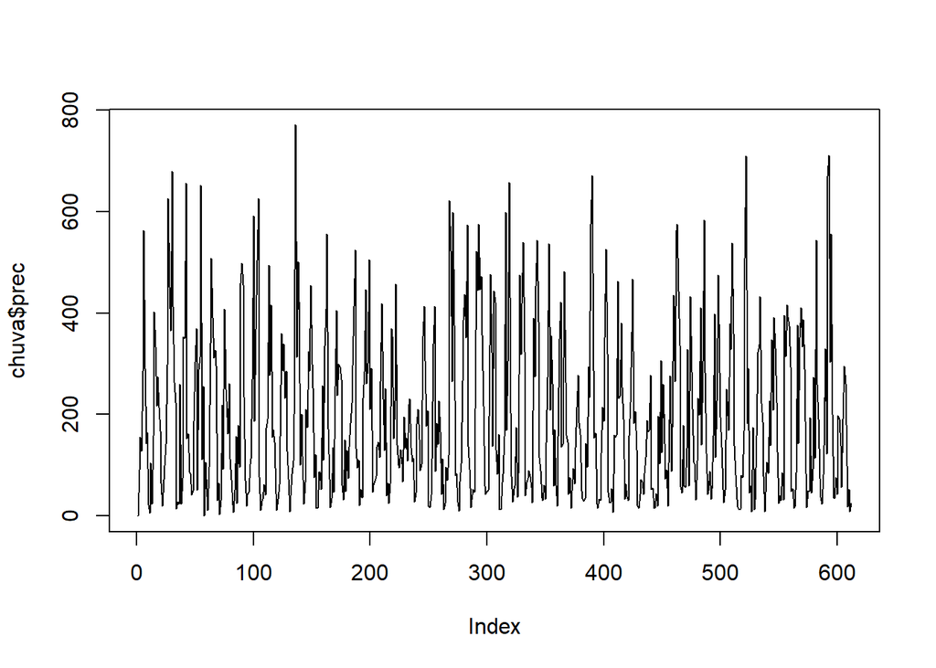

```r
plot(chuva$prec, type = "l")
```

Calculando os SPI's para as escalas 1, 3, 6, 12, 24 e 48.

```r
#escala 1
spi1 <- spi(na.omit(chuva$prec), 1)
#escala 3
spi3 <- spi(na.omit(chuva$prec), 3)
#escala 6
spi6 <- spi(na.omit(chuva$prec), 6)
#escala 12
spi12 <- spi(na.omit(chuva$prec), 12)
#escala 24
spi24 <- spi(na.omit(chuva$prec), 24)
#escala 48
spi48 <- spi(na.omit(chuva$prec), 48)
```

Gráfico das séries dos SPI's.

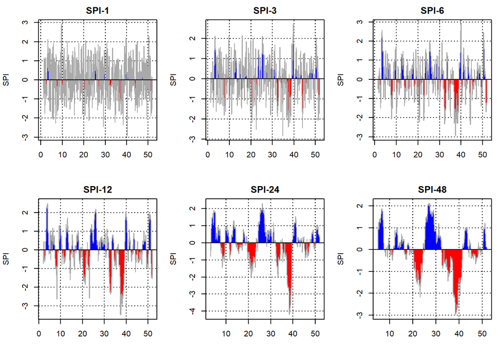

```r
par(mfrow=c(2,3))
plot(spi1, 'SPI-1')
plot(spi3, 'SPI-3')
plot(spi6, 'SPI-6')
plot(spi12, 'SPI-12')
plot(spi24, 'SPI-24')
plot(spi48, 'SPI-48')
```

Histograma das séries dos SPI's.

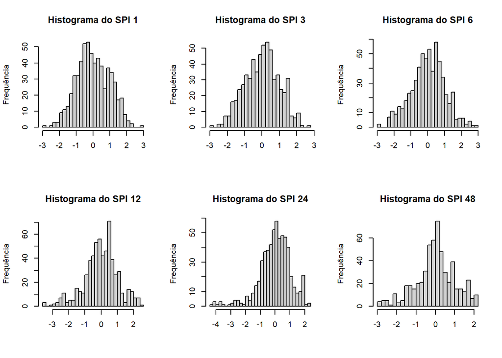

```r
par(mfrow=c(2,3))
hist(spi1$fitted, main="Histograma do SPI 1",xlab=" ", ylab="Frequência", breaks=30)
hist(spi3$fitted, main="Histograma do SPI 3",xlab=" ", ylab="Frequência", breaks=30)
hist(spi6$fitted, main="Histograma do SPI 6",xlab=" ", ylab="Frequência", breaks=30)
hist(spi12$fitted, main="Histograma do SPI 12",xlab=" ", ylab="Frequência", breaks=30)
hist(spi24$fitted, main="Histograma do SPI 24",xlab=" ", ylab="Frequência", breaks=30)
hist(spi48$fitted, main="Histograma do SPI 48",xlab=" ", ylab="Frequência", breaks=30)
```

#### Teste *Mann Kendall*

O teste de Mann-Kendall (Mann, 1945; Kendall, 1975) é um método estatístico não paramétrico (não requer que os dados sigam nenhuma distribuição específica) usado para determinar se uma série temporal tem uma tendência monotônica de crescimento ou decrescimento. É um procedimento baseado em classificação, especialmente adequado para dados que não seguem distribuição normal, dados contendo outliers e tendências não lineares (Birsan et al., 2014). Este teste é baseado na correlação entre os valores das séries temporais e sua ordem temporal, sendo a hipótese nula de que as observações são independentes e distribuídas de forma idêntica (sem tendência), e a hipótese alternativa de que existe uma tendência monotônica (crescente ou decrescente). Para a série temporal $x_1, x_2, \dots, x_n$ o teste de Mann-Kendall usa a estatística

$$\sum_{i=1}^{n-1}\sum_{j=i+1}^{n} sgn(x_j - x_i)$$

onde $x_j$ e $x_i$ são os valores de dados sequenciais, $n$ é o comprimento do conjunto de dados e $sgn(.)$ é representado como segue

$$sgn(x_j - x_i) = \left \{ \begin{matrix} 1, x_j > x_i \\ 0, x_j = x_i \\ -1, x_j < x_i \end{matrix} \right.$$

Partindo do pressuposto de que os dados são independentes e distribuídos de forma idêntica (hipótese nula), a estatística S tem média zero, $E(S) = 0$, e variância dada por

$$Var(S) = \dfrac{1}{18}\bigg[ n(n-1)(2n+5) - \sum_{p=1}^{q} t_p(t_p-1)(2t_p+5) \bigg]$$

em que q é o número de grupos vinculados e $t_p$ é o número de observações no p-ésimo grupo. A estatística de teste Z, que tem uma distribuição normal, é calculada com base nos valores $S$ e $Var(S)$

$$Z = \left \{ \begin{matrix} \dfrac{S-1}{\sqrt{Var(S)}}, S > 0\\
0, S = 0 \\ \dfrac{S+1}{\sqrt{Var(S)}}, S < 0 \end{matrix} \right.$$

Os valores positivos de $Z$ indicam tendências ascendentes, enquanto os valores negativos de $Z$ mostram tendências descendentes. Finalmente, para fins de teste, o valor $p(pv)$ é calculado como

$$pv = 2min(\phi(Z),1-\phi(Z))$$

Calculando o teste *Mann-Kendall* no *R*:

**SPI 1**

O *p-valor* ficou acima de do nível de significância padrão (5%), então aceitamos a hipótese nula e a série do SPI 1 não possui tendência.

```r
print(MannKendall(na.omit(spi1$fitted)))
```

```
## tau = -0.0214, 2-sided pvalue =0.42754
```

```r
print(mk.test(na.omit(spi1$fitted)))
```

```
##
##  Mann-Kendall trend test
##
## data:  na.omit(spi1$fitted)
## z = -0.79341, n = 612, p-value = 0.4275
## alternative hypothesis: true S is not equal to 0
## sample estimates:
##             S          varS           tau
## -4.010000e+03  2.553124e+07 -2.144832e-02
```

**SPI 3**

O *p-valor* ficou acima de do nível de significância padrão (5%), então aceitamos a hipótese nula e a série do SPI 3 não possui tendência.

```r
print(MannKendall(na.omit(spi3$fitted)))
```

```
## tau = -0.0468, 2-sided pvalue =0.083867
```

```r
print(mk.test(na.omit(spi3$fitted)))
```

```
##
##  Mann-Kendall trend test
##
## data:  na.omit(spi3$fitted)
## z = -1.7287, n = 610, p-value = 0.08387
## alternative hypothesis: true S is not equal to 0
## sample estimates:
##             S          varS           tau
## -8.693000e+03  2.528196e+07 -4.680097e-02
```

**SPI 6**

O *p-valor* ficou abaixo de do nível de significância padrão (5%), então aceitamos a hipótese alternativa e a série do SPI 6 possui tendência. A estatística *Z* é um valor negativo, logo a tendência da série é decrescente.

```r
print(MannKendall(na.omit(spi6$fitted)))
```

```
## tau = -0.0622, 2-sided pvalue =0.021947
```

```r
print(mk.test(na.omit(spi6$fitted)))
```

```
##
##  Mann-Kendall trend test
##
## data:  na.omit(spi6$fitted)
## z = -2.2913, n = 607, p-value = 0.02195
## alternative hypothesis: true S is not equal to 0
## sample estimates:
##             S          varS           tau
## -1.143700e+04  2.491107e+07 -6.218498e-02
```

**SPI 12**

O *p-valor* ficou abaixo de do nível de significância padrão (5%), então aceitamos a hipótese alternativa e a série do SPI 12 possui tendência. A estatística *Z* é um valor negativo, logo a tendência da série é decrescente.

```r
print(MannKendall(na.omit(spi12$fitted)))
```

```
## tau = -0.0745, 2-sided pvalue =0.0063308
```

```r
print(mk.test(na.omit(spi12$fitted)))
```

```
##
##  Mann-Kendall trend test
##
## data:  na.omit(spi12$fitted)
## z = -2.7301, n = 601, p-value = 0.006331
## alternative hypothesis: true S is not equal to 0
## sample estimates:
##             S          varS           tau
## -1.342600e+04  2.418023e+07 -7.446478e-02
```

**SPI 24**

O *p-valor* ficou abaixo de do nível de significância padrão (5%), então aceitamos a hipótese alternativa e a série do SPI 24 possui tendência. A estatística *Z* é um valor negativo, logo a tendência da série é decrescente.

```r
print(MannKendall(na.omit(spi24$fitted)))
```

```
## tau = -0.105, 2-sided pvalue =0.00014623
```

```r
print(mk.test(na.omit(spi24$fitted)))
```

```
##
##  Mann-Kendall trend test
##
## data:  na.omit(spi24$fitted)
## z = -3.7974, n = 589, p-value = 0.0001462
## alternative hypothesis: true S is not equal to 0
## sample estimates:
##             S          varS           tau
## -1.811800e+04  2.276171e+07 -1.046279e-01
```

**SPI 48**

O *p-valor* ficou abaixo de do nível de significância padrão (5%), então aceitamos a hipótese alternativa e a série do SPI 48 possui tendência. A estatística *Z* é um valor negativo, logo a tendência da série é decrescente.

```r
print(MannKendall(na.omit(spi48$fitted)))
```

```
## tau = -0.159, 2-sided pvalue =1.5281e-08
```

```r
print(mk.test(na.omit(spi48$fitted)))
```

```
##
##  Mann-Kendall trend test
##
## data:  na.omit(spi48$fitted)
## z = -5.6584, n = 565, p-value = 1.528e-08
## alternative hypothesis: true S is not equal to 0
## sample estimates:
##             S          varS           tau
## -2.536500e+04  2.009328e+07 -1.591984e-01
```

#### Resumo dos resultados

| SPI | Z | *p-valor* | Resultado |
| --- | --- | --- | --- |
| 1 | -0,7934 | 0,4275 | Sem tendência |
| 3 | -1,7287 | 0,0839 | Sem tendência |
| 6 | -2,2913 | 0,0219 | Tendência Negativa |
| 12 | -2,7301 | 0,0063 | Tendência Negativa |
| 24 | -3,7974 | 0,0001 | Tendência Negativa |
| 48 | -5,6584 | 0,0000 | Tendência Negativa |